# EDA - Reclamações ANS e ANATEL

Ronan Souza, Maria Clara Moraes, Oliveiros Neto, Lucas Arcoverde

5/27/2019

## Reclamações

Inserindo colunas de comprimento da reclamacao e do titulo. Além de uma coluna com o número de caracteres em CAPSLOCK

```r
reclamacoes <- reclamacoes %>% mutate(texto.length = str_length(texto),
                                      titulo.length = str_length(titulo))
reclamacoes$numero.de.capslock <- str_count(reclamacoes$texto, "\\b[A-Z]{2,}\\b")
```

### Graficos

Número de reclamações distribuidas pelo tamanho do título

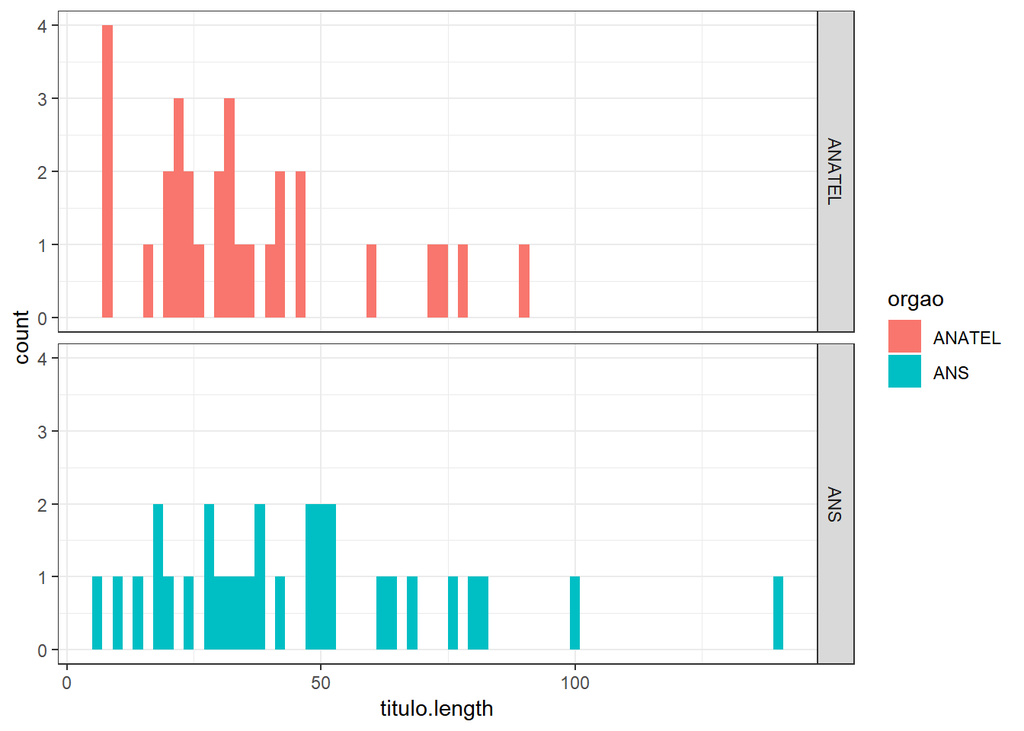

Número de reclamações distribuidas pelo tamanho da reclamação

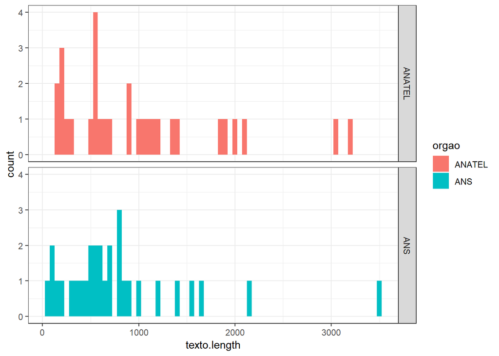

## Avaliações

```r
avaliacoes <- avaliacoes %>%
              select(avaliador = `Matricula`,
                      id = `ID da reclamação`,
                       insatisfacao = `Grau de insatisfação`)
```

```r
avaliacoes %>%
  filter((id %in% 1:5 ))
```

```
## # A tibble: 25 x 3
##    avaliador    id insatisfacao
##        <dbl> <dbl>        <dbl>
##  1 115210091     4            1
##  2 117210350     1            5
##  3 116110322     1            5
##  4 116110076     2            1
##  5 117110810     3            1
##  6 116110899     5            4
##  7 116110761     2            1
##  8 115211049     4            1
##  9 117211057     3            1
## 10 116210009     5            3
## # ... with 15 more rows
```

### Gráficos

Número de avaliações feitas por reclamação

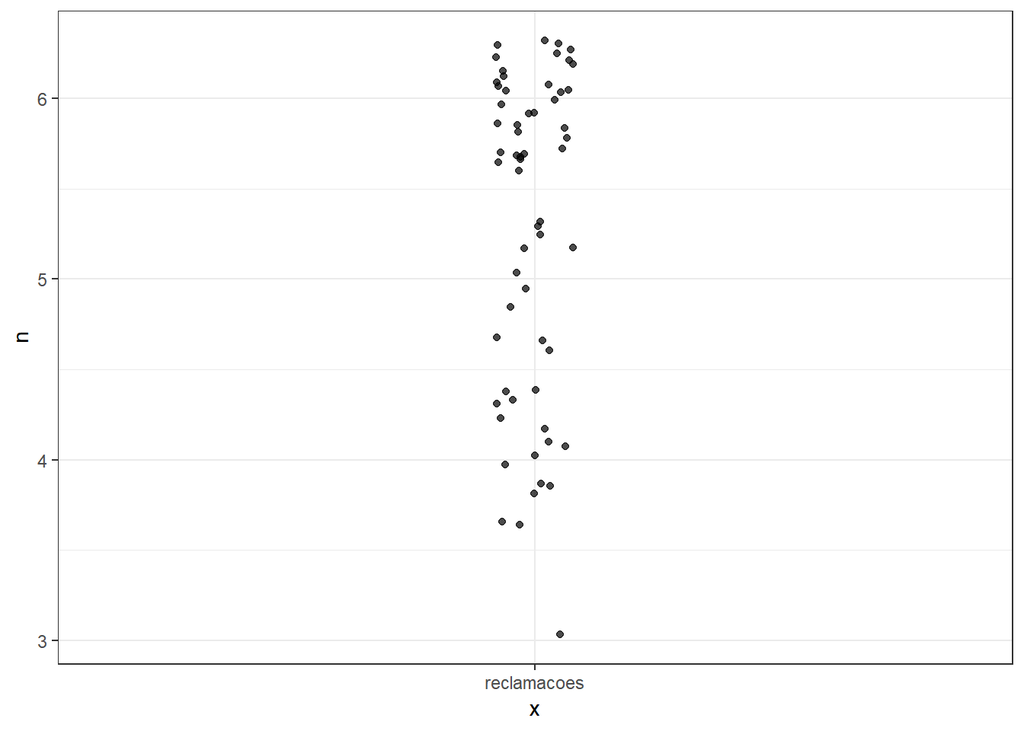

Média de avaliações por reclamação

```r
avaliacoes %>%
  group_by(id) %>%
  count() %>%
  ungroup() %>%
  summarise(media = mean(n),
            mediana = median(n))
```

```
## # A tibble: 1 x 2
##   media mediana
##   <dbl>   <dbl>
## 1  5.27       6
```

Número de revisores por reclamação

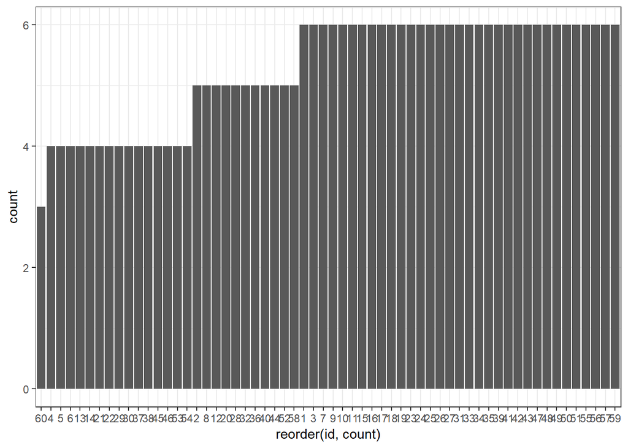

Nível de discordância X ID da reclamação

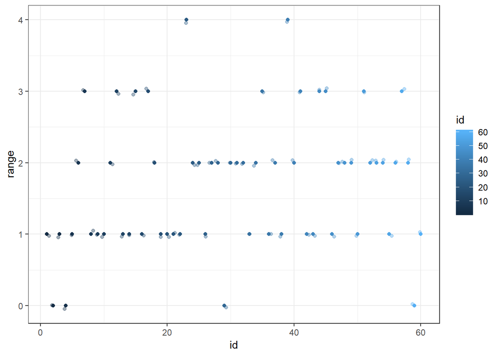

Como podemos ver a baixo, a maioria das avaliações tem nível de discordância 1 ou 2

```r
avaliacoes %>% group_by(id) %>%
  summarise(range = max(insatisfacao) - min(insatisfacao),
            mediana = median(insatisfacao)) %>%
  group_by(range) %>% count()
```

```
## # A tibble: 5 x 2
## # Groups:   range [5]
##   range     n
##   <dbl> <int>
## 1     0     4
## 2     1    23
## 3     2    21
## 4     3    10
## 5     4     2
```

Número de reclamações com discordância maior que 2

```r
avaliacoes %>% group_by(id) %>%
  summarise(range = max(insatisfacao) - min(insatisfacao)) %>%
  filter(range > 2) %>% count()
```

```
## # A tibble: 1 x 1
##       n
##   <int>
## 1    12
```

- Poucas avaliações por reclamação;
- Números obtidos nas avaliações muito próximos;

```r
media <- avaliacoes %>%
  group_by(id) %>%
  summarise(media = median(insatisfacao))

reclamacoes <- reclamacoes %>% mutate(media_insatisfacao = media$media)
```

### Existe relação entre o tamanho do texto da reclamação e a insatisfação do usuário?

- Será que usuários mais insatisfeitos tendem a escrever mais sobre suas insatisfações?

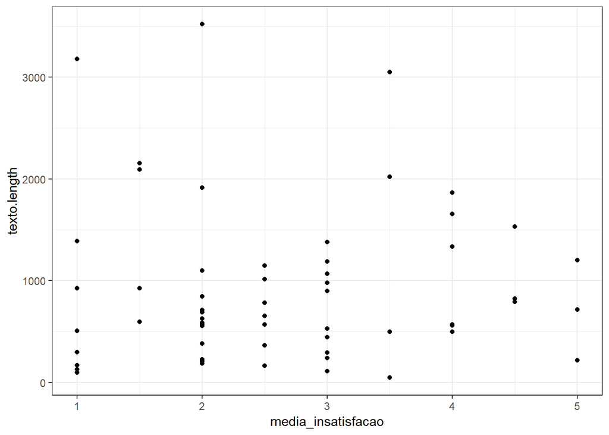

```r
reclamacoes %>% ggplot(aes(x=media_insatisfacao, y=texto.length)) + geom_point()
```

### Existe relação entre o tamanho do titulo da reclamação e a insatisfação do usuário?

- Será que usuários mais insatisfeitos tendem a escrever títulos maiores sobre suas insatisfações?

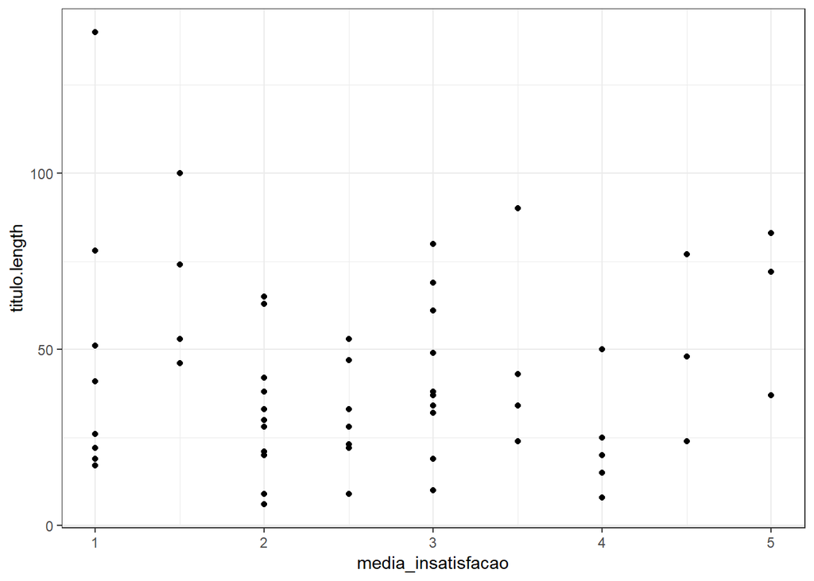

```r
reclamacoes %>% ggplot(aes(x=media_insatisfacao, y=titulo.length)) + geom_point()
```

### Existe relação entre a quantidade de caracteres em CAPSLOCK da reclamação e a insatisfação do usuário?

- Será que usuários tendem a expressar sua insatisfações utilizando as letras em CAPSLOCK?

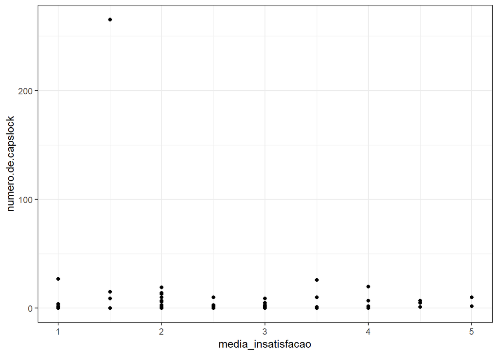

```r
reclamacoes %>% ggplot(aes(x=media_insatisfacao, y=numero.de.capslock)) + geom_point()
```